# Lesson 4

```r
setwd("~/Udacity/dataAnalysisR/EDA_R_Udacity/lesson4")
```

### Load Library and Data Sets

```r
library(ggplot2)
library(gridExtra)
library(dplyr)
library('alr3')
getwd()
```

```
## [1] "C:/Users/Andrew/Documents/Udacity/dataAnalysisR/EDA_R_Udacity/lesson4"
```

```r
list.files()
```

```
## [1] "correlation_images.jpeg" "L4.RData"
## [3] "lesson4_mynotes.html"    "lesson4_mynotes.Rmd"
## [5] "lesson4_student.rmd"     "lesson4_student_files"
```

```r
pf <- read.csv("~/Udacity/dataAnalysisR/EDA_R_Udacity/lesson3/pseudo_facebook.tsv", sep = '\t')
names(pf)
```

```
##  [1] "userid"                "age"
##  [3] "dob_day"               "dob_year"
##  [5] "dob_month"             "gender"
##  [7] "tenure"                "friend_count"
##  [9] "friendships_initiated" "likes"
## [11] "likes_received"        "mobile_likes"
## [13] "mobile_likes_received" "www_likes"
## [15] "www_likes_received"
```

```r
#alternative way to read file read.delim('pseudo_facebook.tsv')
```

### Scatterplots and Perceived Audience Size

Notes:

### Scatterplots

Notes:

```r
#qplot syntax
qplot(age,friend_count,data =pf)
```

[output not shown]

```r
#ggplot syntax
ggplot(aes(x = age, y = friend_count), data = pf) +
  geom_point()
```

[output not shown]

#### What are some things that you notice right away?

Response: Younger people seem to have more friends. There are some people of advanced age with a lot of friends. I’m guessing these are not their actual biological age.

### ggplot Syntax

Notes:

```r
#qplot syntax
qplot(age,friend_count,data =pf)
```

[output not shown]

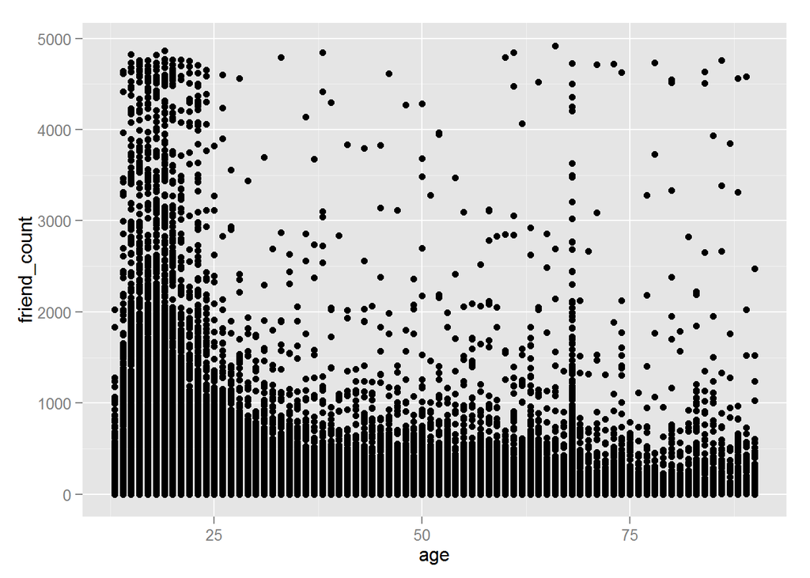

```r
#ggplot syntax
ggplot(aes(x = age, y = friend_count), data = pf) +
  geom_point() +
  xlim(13,90) #min facebook age to reasonable max age
```

```r
summary(pf$age)
```

```
##    Min. 1st Qu.  Median    Mean 3rd Qu.    Max.
##   13.00   20.00   28.00   37.28   50.00  113.00
```

### Overplotting

Notes: We have so many points that it is difficult to see how many points are plotted, especially in the under 30 region. We can use a transparency layer (alpha) to help with this.

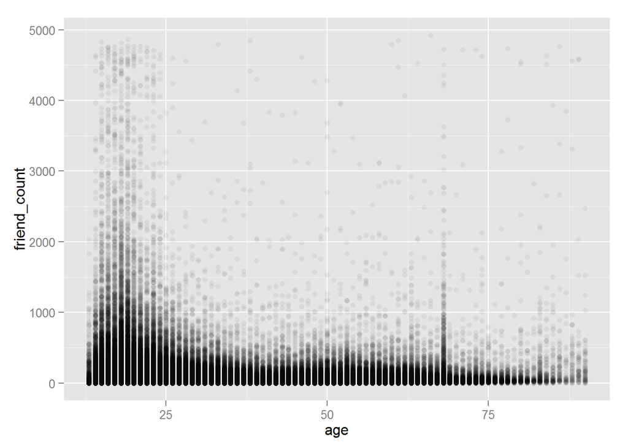

```r
ggplot(aes(x = age, y = friend_count), data = pf) +
  geom_point(alpha = 1/20) + #alpha layer takes 20 points to make a dot completely black
  xlim(13,90) #min facebook age to reasonable max age
```

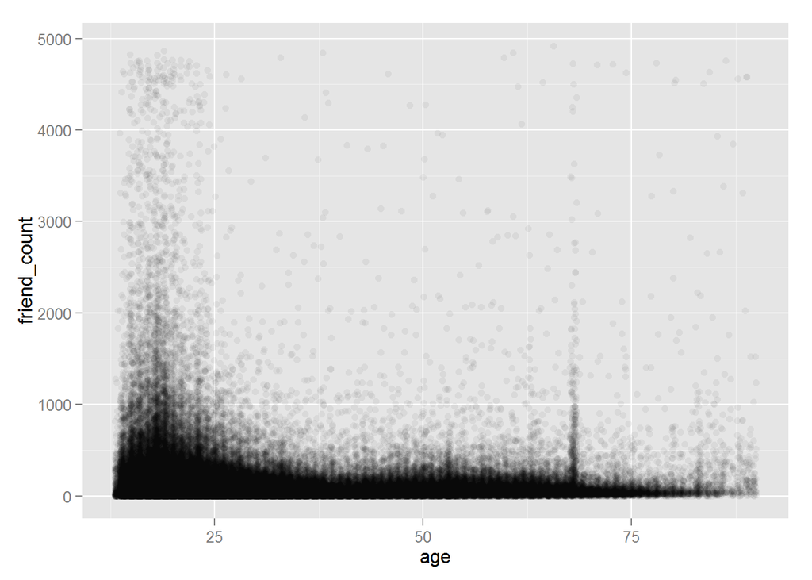

```r
#age is a continuous function but we have stacked columns (discrete), add jitter noise (dispersion) help us getter a better feel for the relationship between age and friend count.

ggplot(aes(x = age, y = friend_count), data = pf) +
  geom_jitter(alpha = 1/20) + #alpha layer takes 20 points to make one black dot
  xlim(13,90)  #min facebook age to reasonable max age
```

#### What do you notice in the plot?

Response:

### Coord_trans()

Notes:

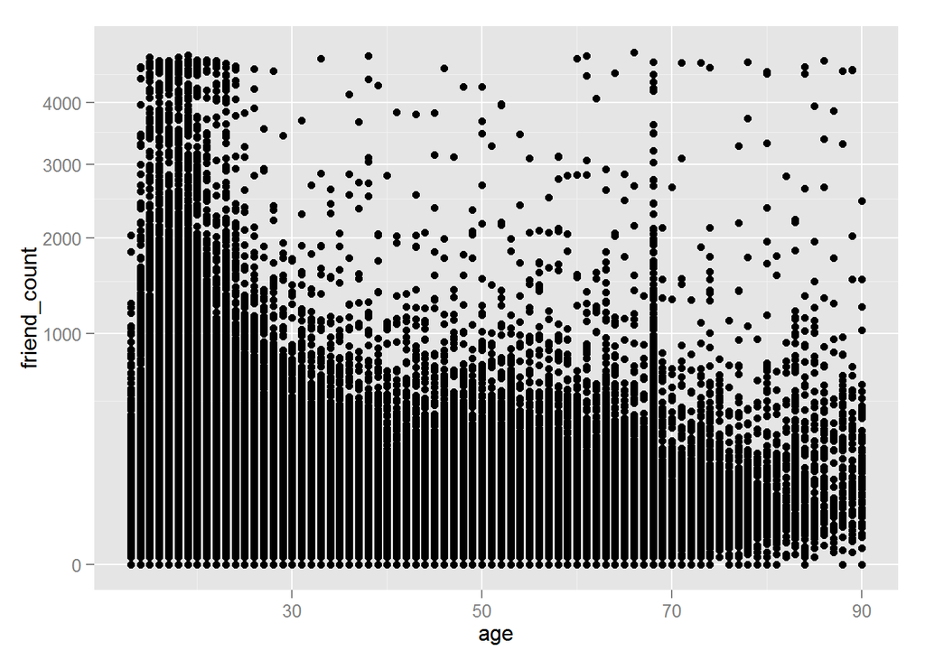

```r
ggplot(aes(x = age, y = friend_count), data = pf) +
  geom_point() +
  xlim(13,90) +
  coord_trans(y = 'sqrt')
```

#### Look up the documentation for coord_trans() and add a layer to the plot that transforms friend_count using the square root function. Create your plot!

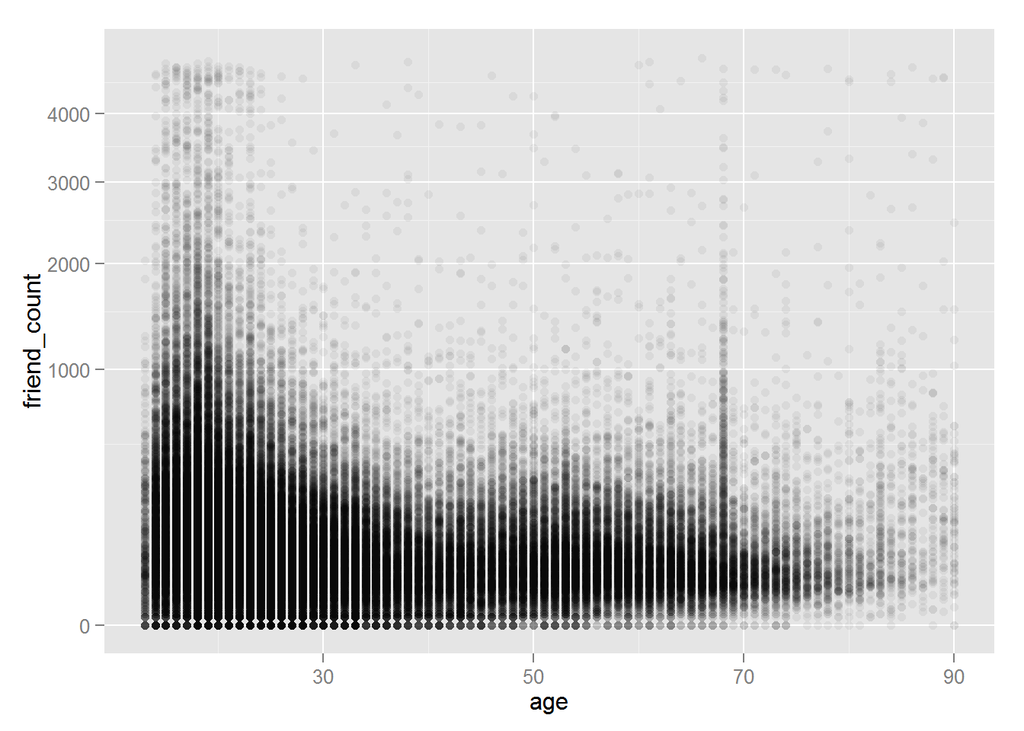

```r
ggplot(aes(x = age, y = friend_count), data = pf) +
  geom_point(alpha = 1/20) +
  xlim(13,90) +
  coord_trans(y = 'sqrt')
```

#### What do you notice?

I noticed that this is not a helpful transformation. ***

### Alpha and Jitter

Notes:

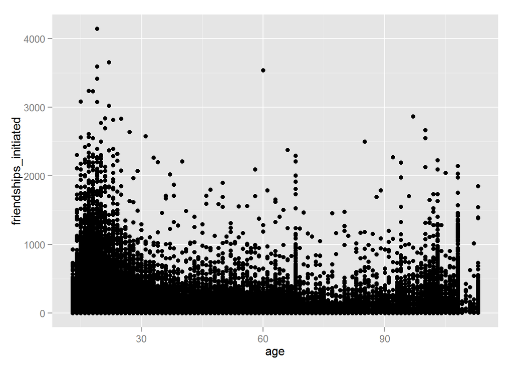

```r
ggplot(aes(x = age, y = friendships_initiated), data = pf) +
  geom_point()
```

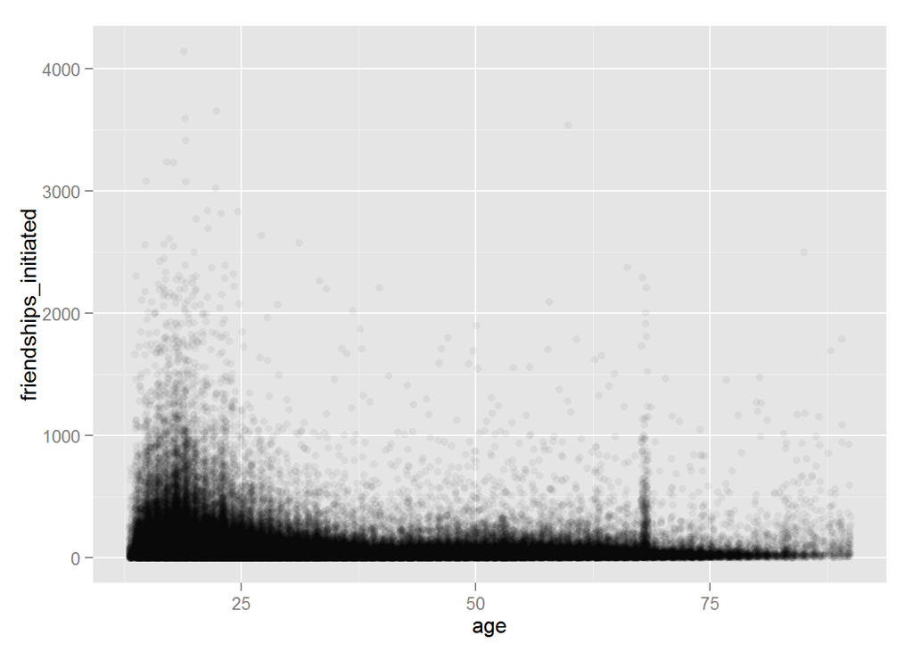

```r
ggplot(aes(x = age, y = friendships_initiated), data = pf) +
  geom_jitter(alpha = 1/20) + #jitter for dispersion appropropriate to continuous var of age
  xlim(13,90)
```

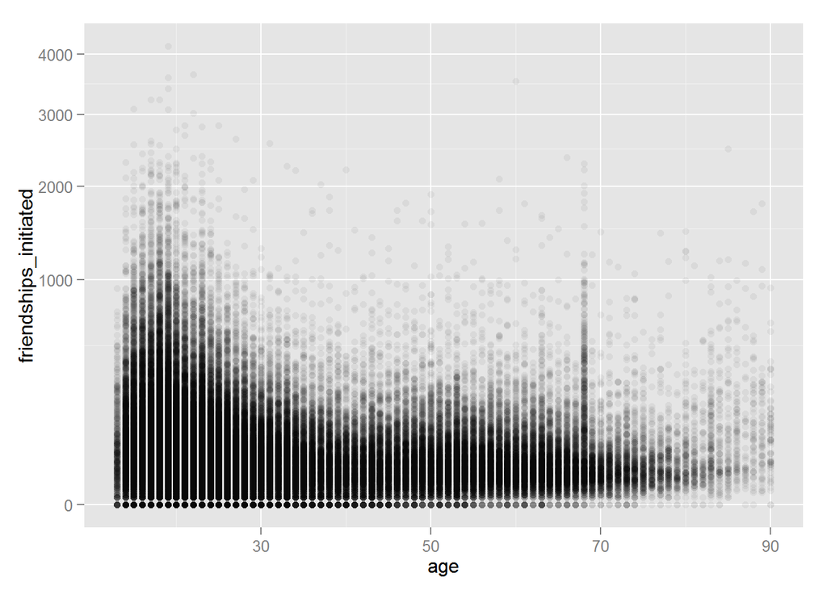

```r
ggplot(aes(x = age, y = friendships_initiated), data = pf) +
  geom_point(alpha = 1/20) + #switch to geom point to avoid -/i numbers
  xlim(13,90) +
  coord_trans(y = 'sqrt')
```

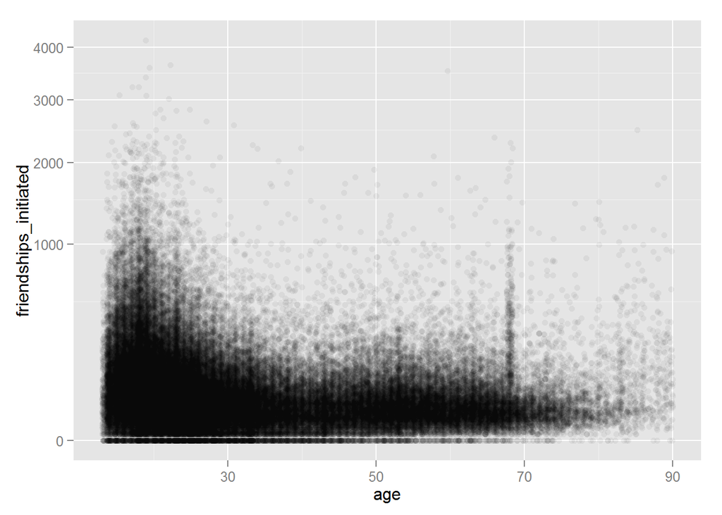

```r
ggplot(aes(x = age, y = friendships_initiated), data = pf) +
  geom_point(alpha = 1/20, position = position_jitter(h = 0)) + #use position and limit to get jitter dispersion without -/i #s
  xlim(13,90) +
  coord_trans(y = 'sqrt')
```

### Overplotting and Domain Knowledge

Notes: Normalizing audience size to % simplified the data.

### Conditional Means

Notes: There are a lot of great links to dplyr infor as well as alternative functions to dplyr, such as split and lapply.

```r
#group_by and some other agg functions using dplyr
#buld the dataframe with a dplyr agg function
age_groups <- group_by(pf,age)
#build the table
pf.fc_by_age <- summarise(age_groups,
                          friend_count_mean = mean(friend_count),
                          friend_count_median = median(friend_count),
                          n = n()) #count function

pf.fc_by_age = arrange(pf.fc_by_age, age) #sort by age

head(pf.fc_by_age)
```

```
## Source: local data frame [6 x 4]
##
##   age friend_count_mean friend_count_median    n
## 1  13          164.7500                74.0  484
## 2  14          251.3901               132.0 1925
## 3  15          347.6921               161.0 2618
## 4  16          351.9371               171.5 3086
## 5  17          350.3006               156.0 3283
## 6  18          331.1663               162.0 5196
```

```r
#an alternative way of creatig the same table by chaining functions onto dataset
pf.fc_by_age <- pf %.%
  group_by(age) %.%
  summarise(friend_count_mean = mean(friend_count),
            friend_count_median = median(friend_count),
            n = n()) %.%
  arrange(age)
head(pf.fc_by_age,20)
```

```
## Source: local data frame [20 x 4]
##
##    age friend_count_mean friend_count_median    n
## 1   13          164.7500                74.0  484
## 2   14          251.3901               132.0 1925
## 3   15          347.6921               161.0 2618
## 4   16          351.9371               171.5 3086
## 5   17          350.3006               156.0 3283
## 6   18          331.1663               162.0 5196
## 7   19          333.6921               157.0 4391
## 8   20          283.4991               135.0 3769
## 9   21          235.9412               121.0 3671
## 10  22          211.3948               106.0 3032
## 11  23          202.8426                93.0 4404
## 12  24          185.7121                92.0 2827
## 13  25          131.0211                62.0 3641
## 14  26          144.0082                75.0 2815
## 15  27          134.1473                72.0 2240
## 16  28          125.8354                66.0 2364
## 17  29          120.8182                66.0 1936
## 18  30          115.2080                67.5 1716
## 19  31          118.4599                63.0 1694
## 20  32          114.2800                63.0 1443
```

Create your plot!

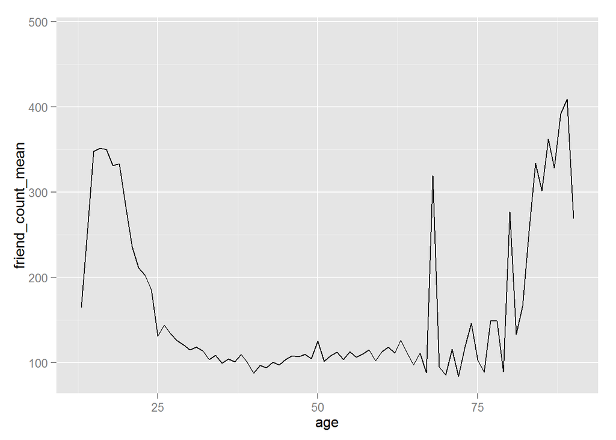

```r
ggplot(aes(x = age, y = friend_count_mean), data = pf.fc_by_age) +
  geom_line() +
  xlim(13,90)
```

### Overlaying Summaries with Raw Data

Notes:

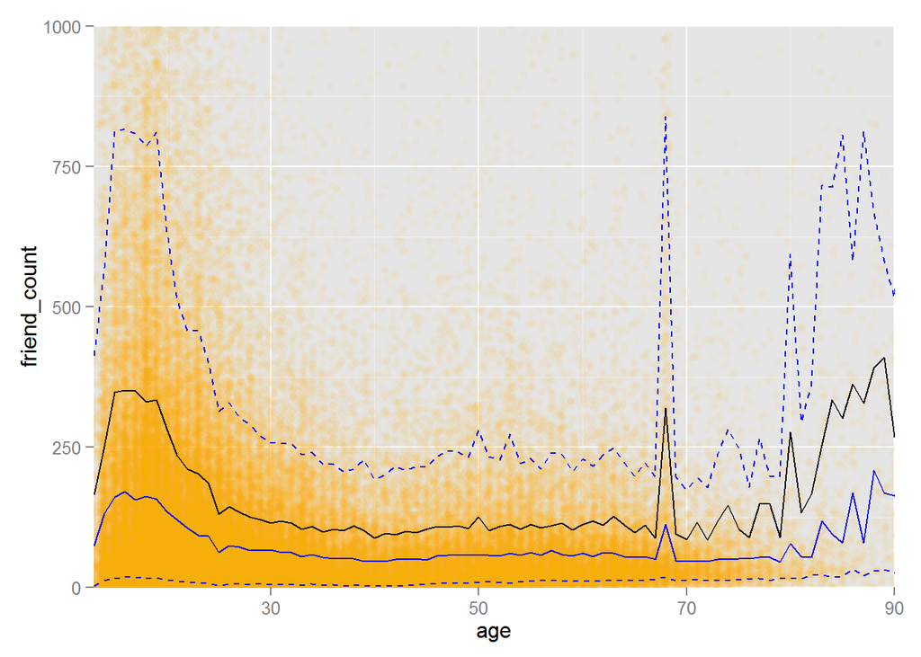

```r
ggplot(aes(x = age, y = friend_count), data = pf) +
  coord_cartesian(xlim = c(13, 90), ylim = c(0,1000)) +
  geom_point(alpha = 1/20, position = position_jitter(h = 0),
             color = 'orange') + #use position and limit to get jitter dispersion without -/i #s
  geom_line(stat = 'summary', fun.y = mean) +
  geom_line(stat = 'summary', fun.y = quantile, probs = .1,
            linetype = 2, color = 'blue') +
  geom_line(stat = 'summary', fun.y = quantile, probs = .5,
            color = 'blue') +
  geom_line(stat = 'summary', fun.y = quantile, probs = .9,
            linetype = 2, color = 'blue')
```

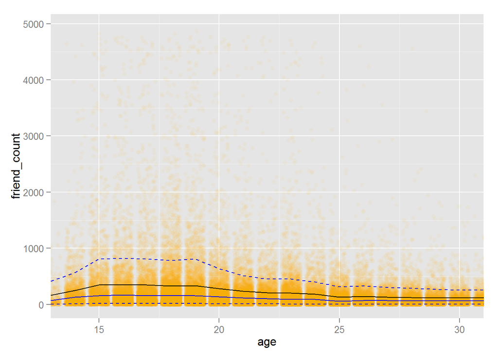

```r
ggplot(aes(x= age, y= friend_count), data = pf) +
  coord_cartesian(xlim = c(13, 31)) +
  geom_point(alpha = 1/20, position = position_jitter(h = 0),
             color = 'orange') +
  geom_line(stat = 'summary', fun.y = mean) +
  geom_line(stat = 'summary', fun.y = quantile, probs = .1,
            linetype = 2, color = 'blue') +
  geom_line(stat = 'summary', fun.y = quantile, probs = .5,
            color = 'blue') +
  geom_line(stat = 'summary', fun.y = quantile, probs = .9,
            linetype = 2, color = 'blue')
```

### Moira: Histogram Summary and Scatterplot

See the Instructor Notes of this video to download Moira’s paper on perceived audience size and to see the final plot.

Notes:

### Correlation

Notes:

```r
cor.test(pf$age, pf$friend_count, method = c('pearson'))
```

```
##
##  Pearson's product-moment correlation
##
## data:  pf$age and pf$friend_count
## t = -8.6268, df = 99001, p-value < 2.2e-16
## alternative hypothesis: true correlation is not equal to 0
## 95 percent confidence interval:
##  -0.03363072 -0.02118189
## sample estimates:
##         cor
## -0.02740737
```

Look up the documentation for the cor.test function.

What’s the correlation between age and friend count? Round to three decimal places. Response: -.027

### Correlation on Subsets

Notes: We should eliminate the higher ages, since we reasonably believe them to be erroneous.

```r
with(subset(pf, pf$age <= 70), cor.test(age, friend_count))
```

```
##
##  Pearson's product-moment correlation
##
## data:  age and friend_count
## t = -52.5923, df = 91029, p-value < 2.2e-16
## alternative hypothesis: true correlation is not equal to 0
## 95 percent confidence interval:
##  -0.1780220 -0.1654129
## sample estimates:
##        cor
## -0.1717245
```

### Correlation Methods

Notes:

## Create Scatterplots

Notes:

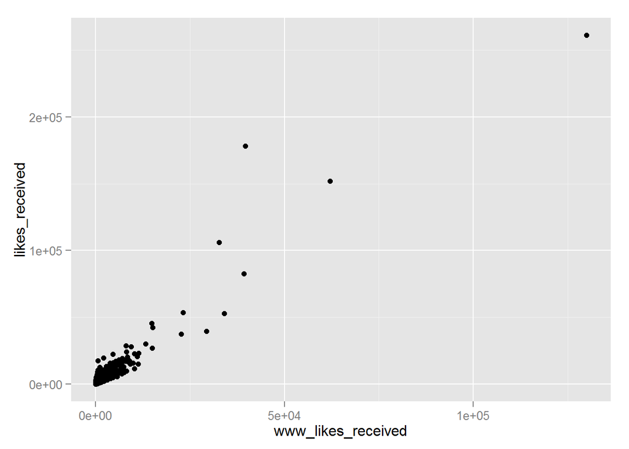

```r
# Create a scatterplot of likes_received (y)
# vs. www_likes_received (x). Use any of the
# techniques that you've learned so far to
# modify the plot.
ggplot(aes(x= www_likes_received, y= likes_received), data = pf) +
  geom_point()
```

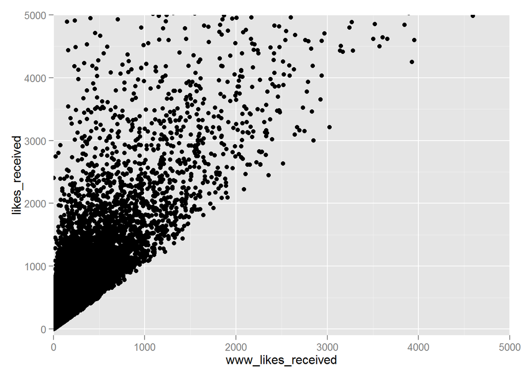

```r
#lets zoom in on the most dense area
ggplot(aes(x= www_likes_received, y= likes_received), data = pf) +
  coord_cartesian(xlim = c(0,5000), ylim = c(-100, 5000)) +
  geom_point()
```

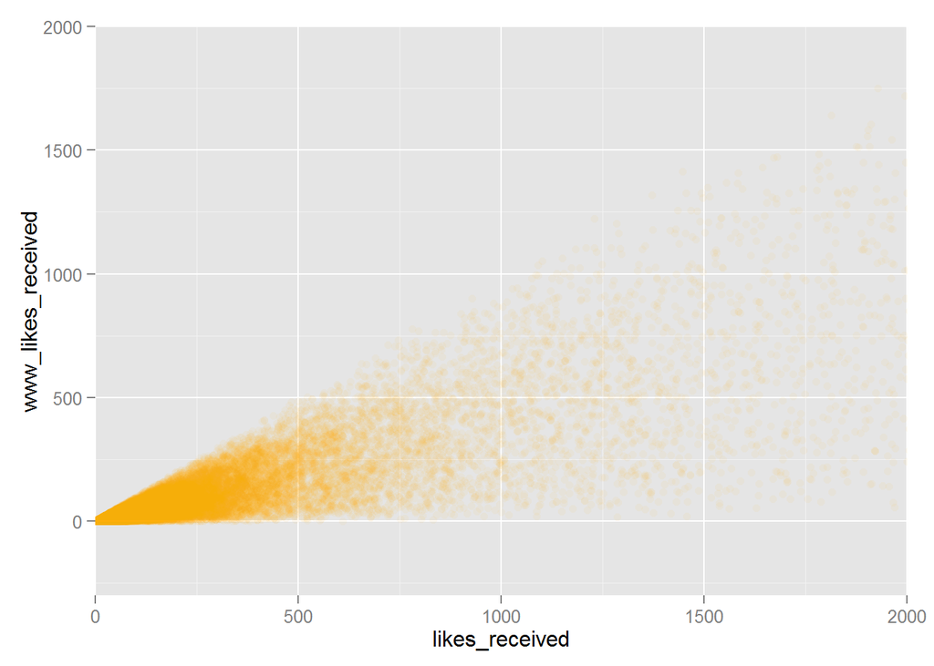

```r
#hard to see the very dense region
ggplot(aes(x= likes_received, y= www_likes_received), data = pf) +
  coord_cartesian(xlim = c(0,2000), ylim = c(-300, 2000)) +
  geom_point(alpha = .05, position = position_jitter(h = 0),
             color = 'orange')
```

### Strong Correlations

Notes:

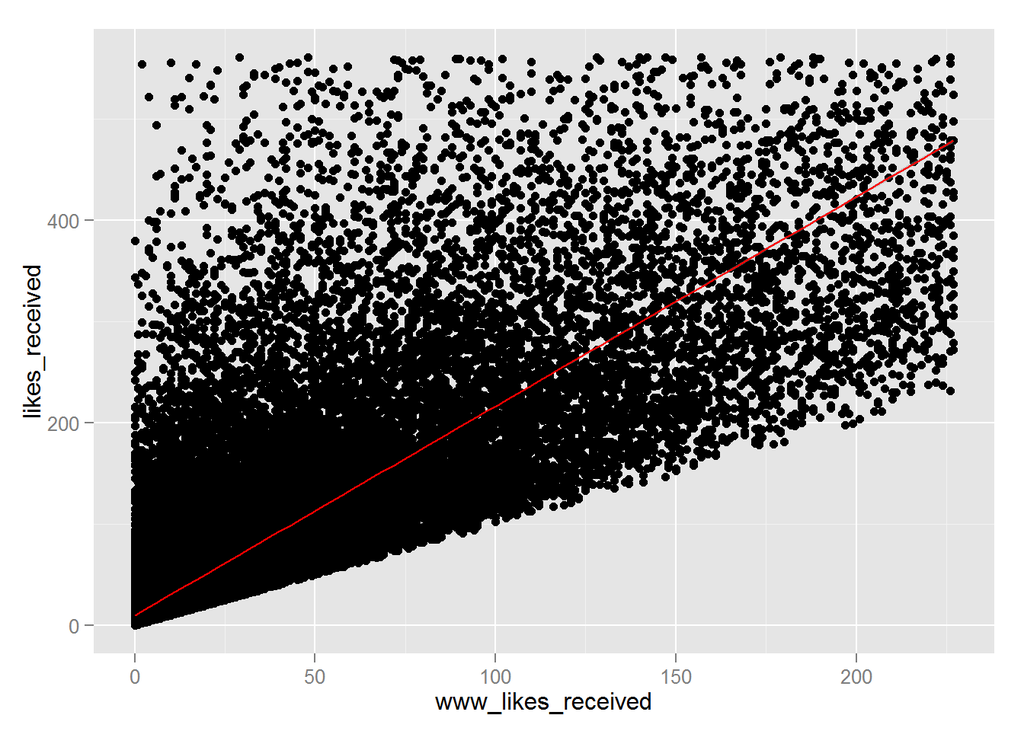

```r
ggplot(aes(x= www_likes_received, y= likes_received), data = pf) +
  geom_point() +
  xlim(0, quantile(pf$www_likes_received,0.95)) +
  ylim(0,quantile(pf$likes_received,0.95)) +
  geom_smooth(method = 'lm',color = 'red')
```

What’s the correlation betwen the two variables? Include the top 5% of values for the variable in the calculation and round to 3 decimal places.

```r
with(pf, cor.test(www_likes_received, likes_received))
```

```
##
##  Pearson's product-moment correlation
##
## data:  www_likes_received and likes_received
## t = 937.1035, df = 99001, p-value < 2.2e-16
## alternative hypothesis: true correlation is not equal to 0
## 95 percent confidence interval:
##  0.9473553 0.9486176
## sample estimates:
##       cor
## 0.9479902
```

Response:

### Moira on Correlation

Notes:

### More Caution with Correlation

Notes:

```r
#install.packages('alr3')
library(alr3)
data(Mitchell)
?Mitchell
```

```
## starting httpd help server ... done
```

```r
head(Mitchell)
```

```
##   Month     Temp
## 1     0 -5.18333
## 2     1 -1.65000
## 3     2  2.49444
## 4     3 10.40000
## 5     4 14.99440
## 6     5 21.71670
```

Create your plot!

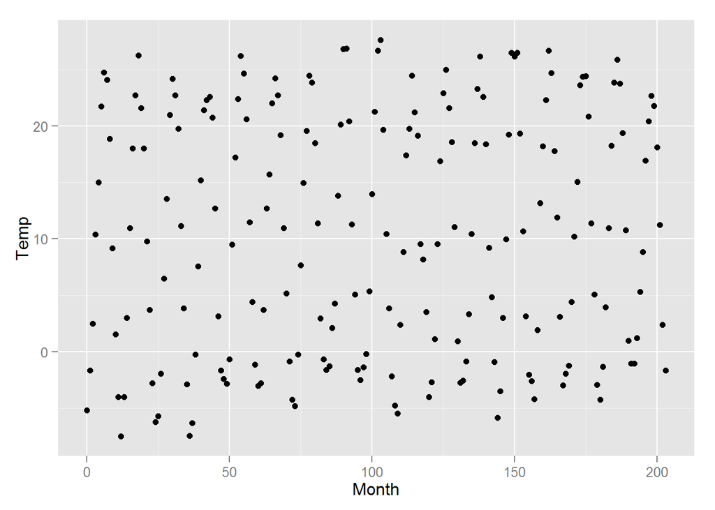

```r
ggplot(aes(x= Month, y= Temp), data = Mitchell) +
  geom_point()
```

### Noisy Scatterplots

1. Take a guess for the correlation coefficient for the scatterplot.

.1

2. What is the actual correlation of the two variables? (Round to the thousandths place)

```r
with(Mitchell,cor.test(Month, Temp))
```

```
##
##  Pearson's product-moment correlation
##
## data:  Month and Temp
## t = 0.8182, df = 202, p-value = 0.4142
## alternative hypothesis: true correlation is not equal to 0
## 95 percent confidence interval:
##  -0.08053637  0.19331562
## sample estimates:
##        cor
## 0.05747063
```

### Making Sense of Data

Notes:

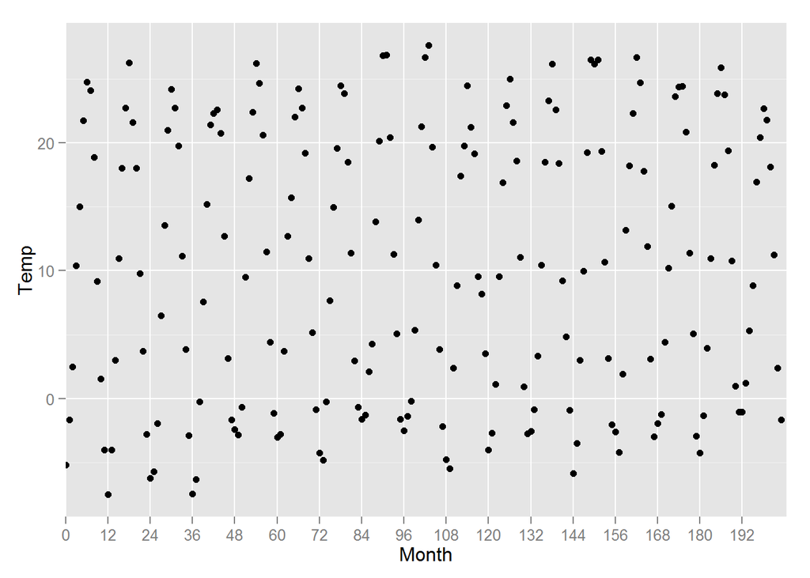

```r
ggplot(aes(x= Month, y= Temp), data = Mitchell) +
  geom_point() +
  scale_x_discrete(breaks = seq(0,203,12)) #found months by typing range(Mitchell$Month) directly into console
```

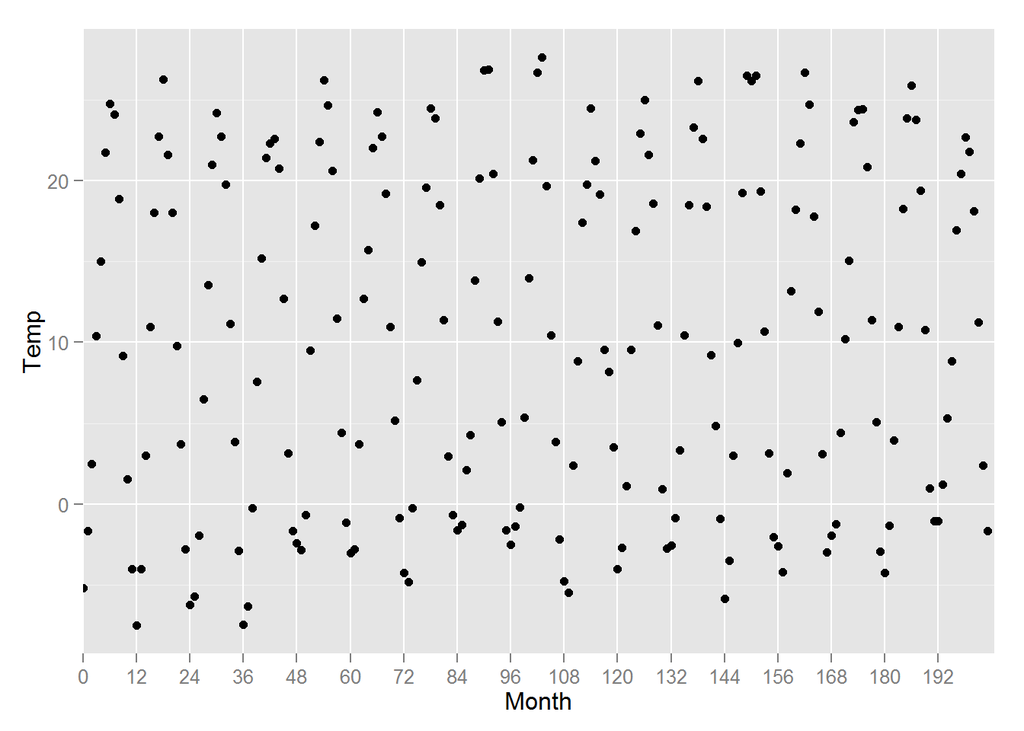

```r
#Let's stretch out the horizontal axis
ggplot(aes(x= Month, y= Temp), data = Mitchell) +
  geom_point() +
  scale_x_discrete(breaks = seq(0,203,12))
```

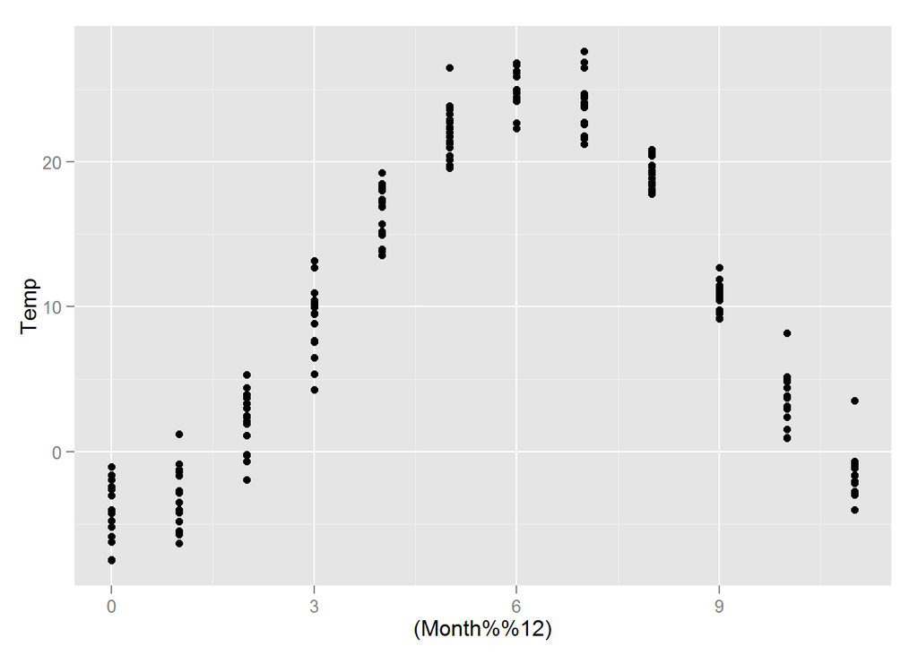

```r
ggplot(aes(x=(Month%%12),y=Temp),data=Mitchell)+
  geom_point()
```

Instructor Notes

You could also get perspective on this data by overlaying each year’s data on top of each other, giving a clear, generally sinusoidal graph. You can do this by using the R’s modulus operator %% in your code. Try running the code below!

ggplot(aes(x=(Month%%12),y=Temp),data=Mitchell)+ geom_point()

Data Visualization Pioneers John Tukey William Playfair William Playfair and the Psychology of Graphs

There are other measures of associations that can detect this. The dcor.ttest() function in the energy package implements a non-parametric test of the independence of two variables. The test correctly rejects the independence. ***

### A New Perspective

What do you notice? Response:

Watch the solution video and check out the Instructor Notes! Notes:

### Understanding Noise: Age to Age Months

Notes:

```r
pf$age_with_months <- pf$age + (1-pf$dob_month/12)
```

### Age with Months Means

Programming Assignment

```r
# Create a new data frame called
# pf.fc_by_age_months that contains
# the mean friend count, the median friend
# count, and the number of users in each
# group of age_with_months. The rows of the
# data framed should be arranged in increasing
# order by the age_with_months variable.

# For example, the first two rows of the resulting
# data frame would look something like...

# age_with_months  friend_count_mean  friend_count_median   n
#              13            275.0000                   275 2
#        13.25000            133.2000                   101 11

pf.fc_by_age_months <- pf %>%
  group_by(age_with_months) %>%
  summarise(friend_count_mean = mean(friend_count),
            friend_count_median = median(friend_count),
            n = n()) %>%
  arrange(age_with_months)

head(pf.fc_by_age_months,20)
```

```
## Source: local data frame [20 x 4]
##
##    age_with_months friend_count_mean friend_count_median   n
## 1         13.16667          46.33333                30.5   6
## 2         13.25000         115.07143                23.5  14
## 3         13.33333         136.20000                44.0  25
## 4         13.41667         164.24242                72.0  33
## 5         13.50000         131.17778                66.0  45
## 6         13.58333         156.81481                64.0  54
## 7         13.66667         130.06522                75.5  46
## 8         13.75000         205.82609               122.0  69
## 9         13.83333         215.67742               111.0  62
## 10        13.91667         162.28462                71.0 130
## 11        14.00000         194.13115               105.0 122
## 12        14.08333         226.67568               106.0 111
## 13        14.16667         270.73611               146.0 144
## 14        14.25000         218.86131               132.0 137
## 15        14.33333         313.24000               148.5 150
## 16        14.41667         230.50000               123.0 160
## 17        14.50000         268.41892               150.5 148
## 18        14.58333         288.51309               153.0 191
## 19        14.66667         264.82927               192.0 164
## 20        14.75000         182.55621               103.0 169
```

### Noise in Conditional Means

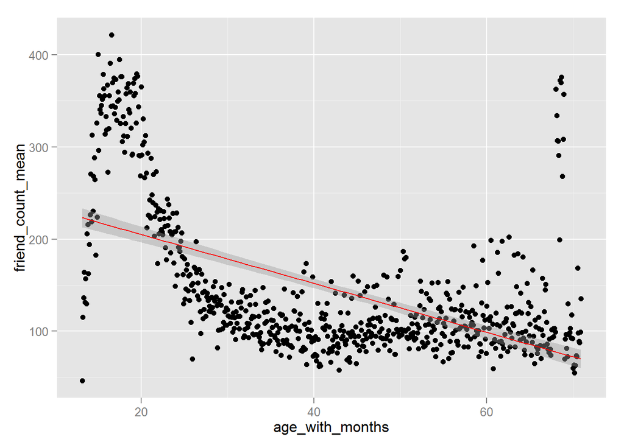

```r
# Create a new scatterplot showing friend_count_mean
# versus the new variable, age_with_months. Be sure to use
# the correct data frame (the one you create in the last
# exercise) AND subset the data to investigate
# users with ages less than 71.

ggplot(aes(x= age_with_months, y= friend_count_mean), data = subset(pf.fc_by_age_months,pf.fc_by_age_months$age_with_months < 71)) +
  geom_point() +
  geom_smooth(method = 'lm',color = 'red')
```

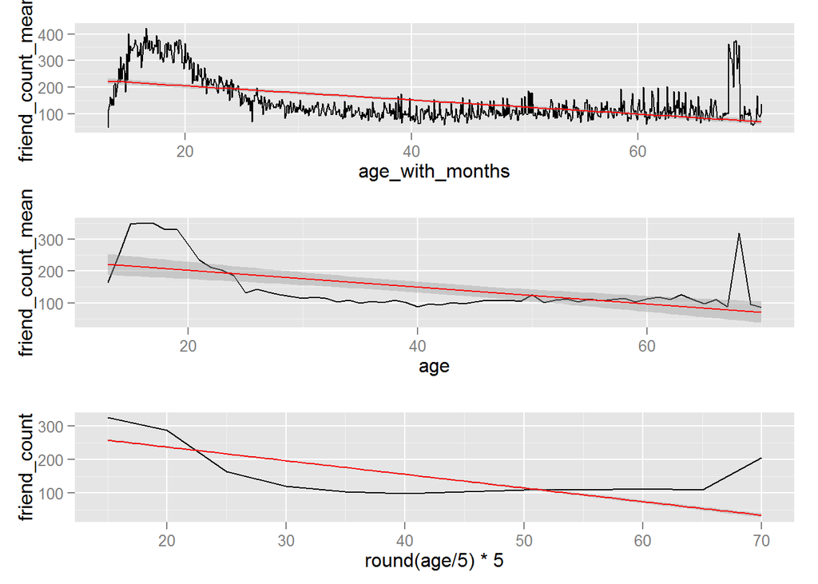

```r
p1 = ggplot(aes(x= age, y= friend_count_mean), data = subset(pf.fc_by_age,pf.fc_by_age$age < 71)) +
  geom_line() +
  geom_smooth(method = 'lm',color = 'red')


p2 = ggplot(aes(x= age_with_months, y= friend_count_mean), data = subset(pf.fc_by_age_months,pf.fc_by_age_months$age_with_months < 71)) +
  geom_line() +
  geom_smooth(method = 'lm',color = 'red')




p3 = ggplot(aes(x= round(age/5)*5, y= friend_count), data = subset(pf,pf$age < 71)) +
  geom_line(stat = 'summary', fun.y = mean) + #plotting mean of friend count rather than friend count
  geom_smooth(method = 'lm',color = 'red')


grid.arrange(p2,p1,p3,ncol=1)
```

```
## geom_smooth: method="auto" and size of largest group is <1000, so using loess. Use 'method = x' to change the smoothing method.
## geom_smooth: method="auto" and size of largest group is <1000, so using loess. Use 'method = x' to change the smoothing method.
## geom_smooth: method="auto" and size of largest group is >=1000, so using gam with formula: y ~ s(x, bs = "cs"). Use 'method = x' to change the smoothing method.
```

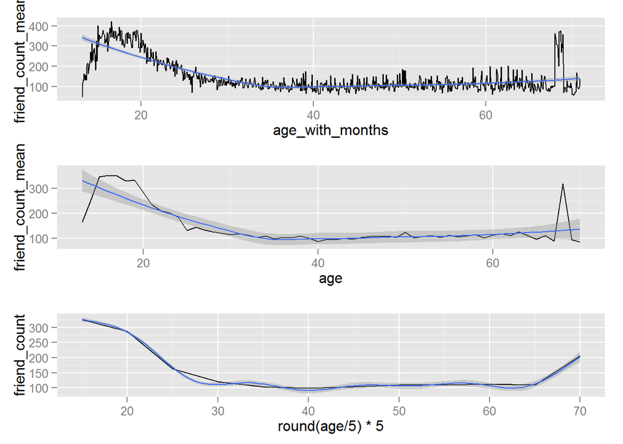

```r
p4 = ggplot(aes(x= age, y= friend_count_mean), data = subset(pf.fc_by_age,pf.fc_by_age$age < 71)) +
  geom_line() +
  geom_smooth()


p5 = ggplot(aes(x= age_with_months, y= friend_count_mean), data = subset(pf.fc_by_age_months,pf.fc_by_age_months$age_with_months < 71)) +
  geom_line() +
  geom_smooth()


p6 = ggplot(aes(x= round(age/5)*5, y= friend_count), data = subset(pf,pf$age < 71)) +
  geom_line(stat = 'summary', fun.y = mean) + #plotting mean of friend count rather than friend count
  geom_smooth()

grid.arrange(p5,p4,p6,ncol=1)
```

Looking at the 3 plots the top one (p2) has more bins (age in months), the middle plot (p1, age in years) has less bins, it is smoother. For plot 3 we lump everyone together whose age falls on a multiple of five. For example, users who are within 2.5 years of 40, 50, and 60 will be lumped together, respectively. Look at Local Regression (LOESS) explained visually on the Simply Statistics blog. Now we have less data points and wider bin widths. We may now be able to estimate more accurately but have lost some of the interesting features of the age and friend_count relationship. This is bias variance tradeoff. A better way to handle the noise is to use a smooth function. Using these functions, splines etc. makes the assumption that the true data is smooth. In this case it isn’t, so while it does smooth out the noise, we miss the nonmontonic features of the low age ranges and the spike at age 69.

The Details of Loess and Lowess ***

### Smoothing Conditional Means

Notes:

### Which Plot to Choose?

Notes:

### Analyzing Two Variables

Reflection:

Click **KnitHTML** to see all of your hard work and to have an html page of this lesson, your answers, and your notes!